# MFPCA & GAMM for UTI

We can look at all of this in a trajectory plot as well, this will show us both dimensions in one plot:

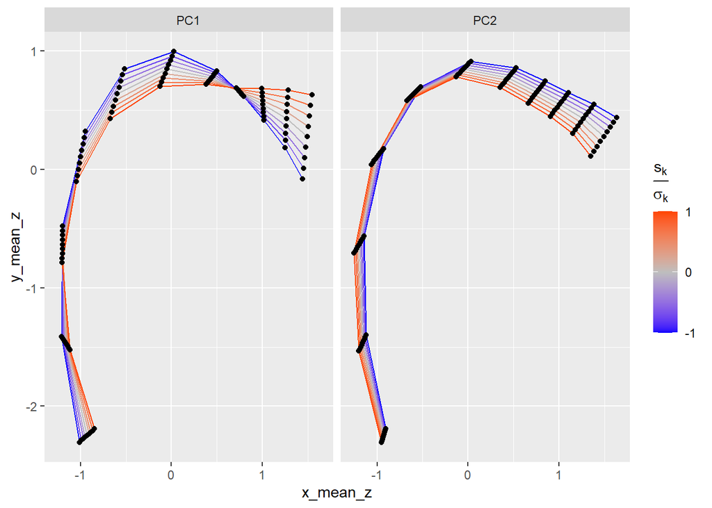

```r
FPCA_knot_traj_plot <- ggplot(PCcurves_xy %>% pivot_wider(names_from = dim, values_from = y) %>% filter(knot %in% c(0,1,2,3,4,5,6,7,8,9,10))) +
  aes(x = x_mean_z, y = y_mean_z, group = fractionOfStDev, color = fractionOfStDev) +
  geom_path() + geom_point(colour = "black") +
  scale_color_gradient2(low = "blue", mid = "grey", high = "orangered",
                        breaks = c(-1, 0 , 1)) +
  facet_grid(. ~ PC,
             # scales = "free_y",
             labeller = labeller(PC = ~ str_glue("PC{.x}"))) +
  labs(color = expression(frac(s[k], sigma[k]))) +
  theme(legend.position = "right")

FPCA_knot_traj_plot
```

*Differences between the speakers*

Our first goal is to see if there is a difference between the speakers. Since the use of uvular and alveolar rhotics is typically speaker-specific, we should see clear differences in the PC1 and PC2 scores of the speakers when we compare them with each other. Speakers using (mainly) alveolar rhotics should have a higher PC1 and a lower PC2 score overall, if our theory explained above is correct. Speakers using (mainly) uvular rhotics should have a lower PC1 and a higher PC2 score in comparison.

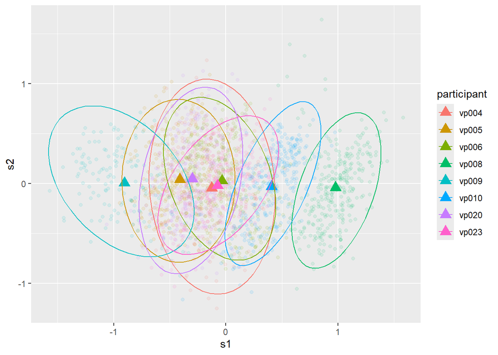

```r
nPC = 5
# collect PC scores
PCscores_xy <- mfpca$scores %>%
  `colnames<-`(paste0("s", 1:nPC)) %>%
  as_tibble() %>%
  bind_cols(curves_xy %>% distinct(filename, frame_id, participant), .)
# note that the PC scores are the same for both dimensions

# scatterplot PC scores s1 and s2 by participant
pc_mean <- PCscores_xy %>%
  group_by(participant) %>%
  summarise(
    mean_s1 = mean(s1),
    mean_s2 = mean(s2),
    mean_s3 = mean(s3)
  ) %>%
  ungroup()

PCscores_per_participants_plot <- ggplot(PCscores_xy) +
  aes(x = s1, y = s2, color = participant) +
  geom_point(alpha = 0.1) +
  geom_point(data = pc_mean, mapping = aes(x = mean_s1, y = mean_s2, color = participant),pch = 17, size = 4) +
  stat_ellipse() +
  theme(legend.position = "right")

PCscores_per_participants_plot
```

In general, we can observe that the participants differ a lot in the PC1 score (s1), but seem to not differ much at all in regards to the PC2 score (s2). So the differences in s2 seem not to be speaker-specific

We can also plot the PC scores as boxplots. In this case we will have a short look at all 5 PC scores that we calculated, to see if there might be another PC score that correlates even more to the variable `participant` than the PC1 score:

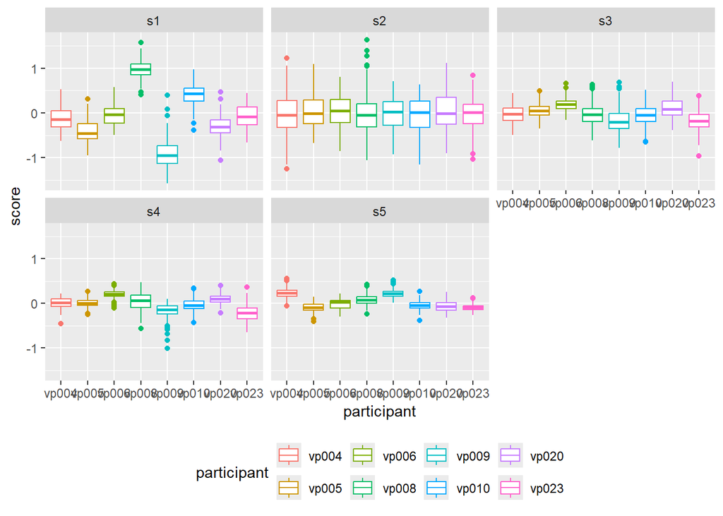

```r
FPCA_knot_scores_plot <- PCscores_xy %>%
  pivot_longer(cols = paste0("s", 1:nPC),
               names_to = "PC", values_to = "score") %>%
  ggplot() +
  aes(x = participant, y = score, color = participant) +
  geom_boxplot() +
  facet_wrap(~ PC) +
  theme(legend.position = "bottom")

FPCA_knot_scores_plot
```

It looks like s1 has the biggest correlation to the variable `participant`, while s2 looks like it has none at all. The other PC scores look like they vary a *bit* between speakers. It might make sense to look into this more in future analyses.

For now, we take a look at the PC1 score. Participant 9 has the lowest s1, Participant 8 has the highest s1. As described above, a high s1 describes a lowering of the tongue in the uvular region and a raising of the tongue in the alveolar region what could be interpreted as the pronunciation of an alveolar rhotic (e.g. an alveolar trill). A low s1 describes the opposite - a high tongue dorsum and a low tongue tip, what would be the case for uvular rhotics (e.g. uvular fricatives).

The other participants have a s1 that lays between those of Participant 9 and 8.

*Linear Model*

```r
s <- 1 # score index
model_eq <- str_glue("s{s} ~ participant") %>% as.formula()
mod <- lm(model_eq, data = PCscores_xy)
mod %>% summary()
```

```
##
## Call:
## lm(formula = model_eq, data = PCscores_xy)
##
## Residuals:
##      Min       1Q   Median       3Q      Max
## -0.79188 -0.16150 -0.00913  0.15045  1.30033
##
## Coefficients:
##                  Estimate Std. Error t value Pr(>|t|)
## (Intercept)      -0.12524    0.01858  -6.740 2.02e-11 ***
## participantvp005 -0.28466    0.02269 -12.543  < 2e-16 ***
## participantvp006  0.09125    0.02266   4.027 5.84e-05 ***
## participantvp008  1.10267    0.02290  48.155  < 2e-16 ***
## participantvp009 -0.77934    0.02619 -29.756  < 2e-16 ***
## participantvp010  0.53215    0.02266  23.485  < 2e-16 ***
## participantvp020 -0.17391    0.02261  -7.691 2.20e-14 ***
## participantvp023  0.05129    0.02264   2.266   0.0236 *
## ---
## Signif. codes:  0 '***' 0.001 '**' 0.01 '*' 0.05 '.' 0.1 ' ' 1
##
## Residual standard error: 0.2291 on 2154 degrees of freedom
## Multiple R-squared:  0.8275, Adjusted R-squared:  0.8269
## F-statistic:  1476 on 7 and 2154 DF,  p-value: < 2.2e-16
```

```r
emmeans(mod, pairwise ~ participant)
```

```
## $emmeans
##  participant emmean     SE   df lower.CL upper.CL
##  vp004       -0.125 0.0186 2154  -0.1617 -0.08880
##  vp005       -0.410 0.0130 2154  -0.4355 -0.38434
##  vp006       -0.034 0.0130 2154  -0.0594 -0.00855
##  vp008        0.977 0.0134 2154   0.9512  1.00368
##  vp009       -0.905 0.0185 2154  -0.9408 -0.86838
##  vp010        0.407 0.0130 2154   0.3815  0.43234
##  vp020       -0.299 0.0129 2154  -0.3244 -0.27388
##  vp023       -0.074 0.0129 2154  -0.0993 -0.04860
##
## Confidence level used: 0.95
##
## $contrasts
##  contrast      estimate     SE   df t.ratio p.value
##  vp004 - vp005   0.2847 0.0227 2154  12.543  <.0001
##  vp004 - vp006  -0.0913 0.0227 2154  -4.027  0.0015
##  vp004 - vp008  -1.1027 0.0229 2154 -48.155  <.0001
##  vp004 - vp009   0.7793 0.0262 2154  29.756  <.0001
##  vp004 - vp010  -0.5321 0.0227 2154 -23.485  <.0001
##  vp004 - vp020   0.1739 0.0226 2154   7.691  <.0001
##  vp004 - vp023  -0.0513 0.0226 2154  -2.266  0.3132
##  vp005 - vp006  -0.3759 0.0184 2154 -20.446  <.0001
##  vp005 - vp008  -1.3873 0.0187 2154 -74.271  <.0001
##  vp005 - vp009   0.4947 0.0226 2154  21.893  <.0001
##  vp005 - vp010  -0.8168 0.0184 2154 -44.428  <.0001
##  vp005 - vp020  -0.1107 0.0183 2154  -6.043  <.0001
##  vp005 - vp023  -0.3359 0.0184 2154 -18.302  <.0001
##  vp006 - vp008  -1.0114 0.0186 2154 -54.273  <.0001
##  vp006 - vp009   0.8706 0.0226 2154  38.591  <.0001
##  vp006 - vp010  -0.4409 0.0183 2154 -24.039  <.0001
##  vp006 - vp020   0.2652 0.0183 2154  14.504  <.0001
##  vp006 - vp023   0.0400 0.0183 2154   2.182  0.3627
##  vp008 - vp009   1.8820 0.0228 2154  82.544  <.0001
##  vp008 - vp010   0.5705 0.0186 2154  30.615  <.0001
##  vp008 - vp020   1.2766 0.0186 2154  68.713  <.0001
##  vp008 - vp023   1.0514 0.0186 2154  56.505  <.0001
##  vp009 - vp010  -1.3115 0.0226 2154 -58.134  <.0001
##  vp009 - vp020  -0.6054 0.0225 2154 -26.893  <.0001
##  vp009 - vp023  -0.8306 0.0225 2154 -36.858  <.0001
##  vp010 - vp020   0.7061 0.0183 2154  38.619  <.0001
##  vp010 - vp023   0.4809 0.0183 2154  26.260  <.0001
##  vp020 - vp023  -0.2252 0.0183 2154 -12.337  <.0001
##
## P value adjustment: tukey method for comparing a family of 8 estimates
```

The `emmeans` function shows us that there are significant differences in the PC1 scores of all the contrast except for the contrast between participant 4 and participant 23 (p = 0.3132) and participant 6 and 23 (p = 0.3627). [Note: This is actually interesting because participant 23 uses an alveolar rhotic while 4 and 6 use an uvular rhotic, so we would expect 4 and 6 to be different from 23. Maybe this variation is covered by one of the other PC scores?]

```r
predCurves <- emmeans(mod, pairwise ~ participant)$emmeans %>%
  as_tibble() %>%
  expand_grid(dim = 1:2) %>%
  group_by(participant, dim) %>%
  reframe(bind_cols(
    funData2long1(mfpca$meanFunction[[dim]] +
                    emmean * mfpca$functions[[dim]][s], time = "knot", value = "y"),
    funData2long1(mfpca$meanFunction[[dim]] +
                    lower.CL * mfpca$functions[[dim]][s], time = "knot", value = "y_l") %>%
      select(y_l),
    funData2long1(mfpca$meanFunction[[dim]] +
                    upper.CL * mfpca$functions[[dim]][s], time = "knot", value = "y_u") %>%
      select(y_u)
  )) %>%
  mutate(dim = factor(dim, levels = c(1,2), labels = c('x_mean_z', 'y_mean_z'))) %>%
  pivot_wider(names_from = dim, values_from = starts_with("y"))


FPCA_knot_pred_plot <- ggplot(predCurves) +
  aes(group = participant, color = participant) +
  geom_path(aes(x = y_x_mean_z, y = y_y_mean_z)) +
  geom_path(aes(x = y_l_x_mean_z, y = y_l_y_mean_z), linetype = "dotted") +
  geom_path(aes(x = y_u_x_mean_z, y = y_u_y_mean_z), linetype = "dotted") +
  xlab("x_mean_z") + ylab("y_mean_z") +
  theme(legend.position = "bottom")
```

The predicted plots from the linear model for the participants looks like this:

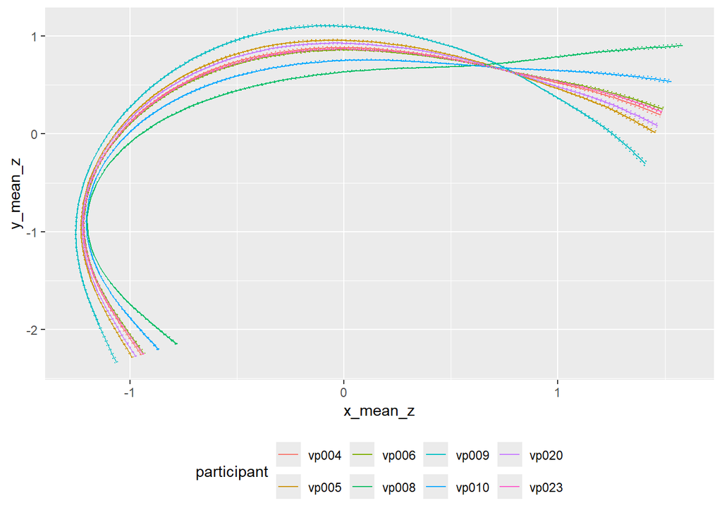

```r
FPCA_knot_pred_plot
```

In comparison with the GAM prediction, this looks very similar in general. But it’s interesting to see that there are also differences. Especially participant 23 looks a lot different here than in the GAM prediction plot. In the MFPCA prediction, the shape of participant 23 is very close to participants 4 and 6, while in the GAM prediction, the tongue tip went more upwards and the general shape looked more like that of participant 10.

Keep in mind that this plot only includes the variation that is described by PC1 and does not include the variation of other PCs.

## dynamic data

After the static analyses, we will now try to expand the models so they include the time axis as well. The time variable is another independent variable in our data set.

Read in the (cartesian) data set:

```r
rhotic_data <- readRDS("../data/RDS/rhotic_data.rds")
```

When we pick one rhotic, we can observe how the tongue moves over time. Here’s the example of the /r/ in the word “*R*otation” being articulated by all of the participants:

```r
dynamic_data_example <- rhotic_data |> filter(target == "Rotation") %>%
  ggplot(aes(x_z, y_z, group = frame_id_file, colour = normtime)) +
  coord_cartesian() +
  geom_point() +
  geom_path(alpha = 0.5) +
  facet_wrap(vars(participant), ncol = 4)
```

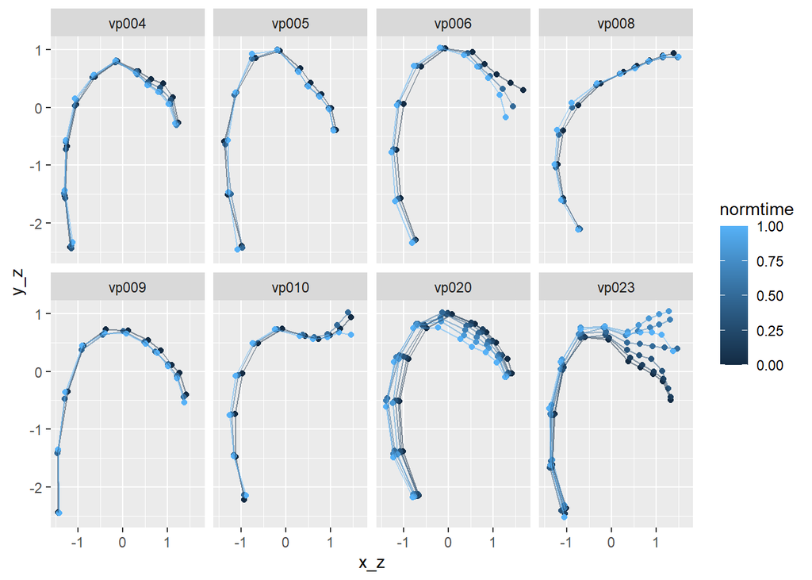

```r
dynamic_data_example
```

In this plot, the dark blue color marks the beginning of the rhotic, the light blue color the end of the rhotic. It can be observed that most of the participants lower their tongue (or at least their tongue tip) during the articulation of the rhotic – the only exception being participant 23, who raises their tongue and only lowers it in the very last frame.

### GAMM

#### polar coordinates

Read in the data set containing the dynamic polar coordinates:

```r
rhotic_data_polar <- readRDS("../data/RDS/rhotic_data_polar_dyn.rds")
```

We will again perform a Procrustean angle normalization (Gubian 2025):

```r
angle_range <- rhotic_data_polar  %>%
  filter(knot %in% range(knot)) %>% # first and last knot
  group_by(knot) %>%
  summarise(median_angle = median(angle)) %>%
  pull(median_angle) %>%
  sort()

angle_grid <- seq(angle_range[1], angle_range[2], length.out=11)

proc_polar_curves <- rhotic_data_polar  %>%
  group_by(participant, clip_id, normtime, target) %>%
  # interpolation
  reframe(bind_cols(
    knot = seq(along.with = angle_grid, from = 0), # fake knots, needed for AR1 term in GAM
    approx(angle, radius, angle_grid, rule = 2) %>% as_tibble()
    )) %>%
  rename(angle = x,radius = y)
```

Now we can plot one example of the polar data. As above, we choose the example target “*R*otation”

```r
dataset_ex_flat <- proc_polar_curves %>% filter(target == "Rotation") %>%
  ggplot() +
  aes(x = angle, y= normtime) +
  geom_raster(aes(fill = radius)) +
  facet_grid(~ participant) +
  scale_x_reverse() +
  scale_fill_gradientn(colours = terrain.colors(10))
```

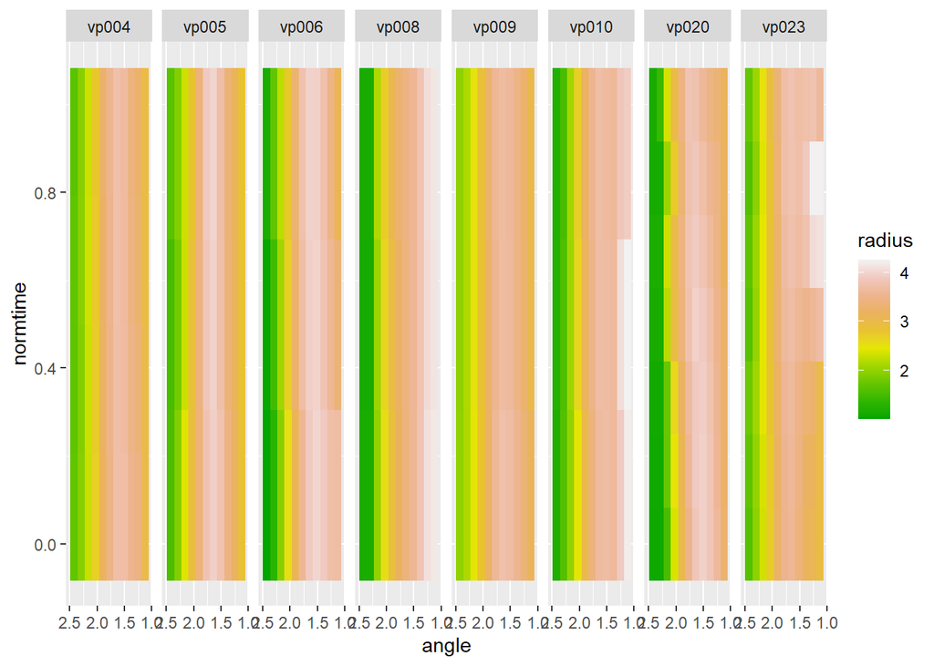

```r
dataset_ex_flat
```

What do we see?

- y-axis: normtime – at the bottom is the start of the rhotic, at the top is the end of the rhotic
- x-axis: angle – on the left of each plot is the biggest angle = the left side of the tongue = tongue root. At the right side of each plot is the smallest angle = right side of the tongue = tongue tip.
- color: radius – green = small radius = tongue is close to the origin; yellow-ish/brown-ish = medium radius = tongue is a bit further away from the origin; white = large radius = tongue is far away from the origin

an example: We’re looking at the tongue tip of participant 6, so the rightmost part of their plot that has the smallest angle. At the bottom (at 0 (%) of the normtime), the plot starts with a very light-brown color. That’s the very start of the rhotic. This means that the tongue tip has to be far away from the origin, so it’s probably a bit raised in the beginning. If we follow the tongue tip to the top, so up to the end (time-wise) of the rhotic, we can observe that the color becomes a darker brown over time and even gets a bit yellow-ish at the very top (at 100 %). That means that the radius gets smaller, so the tongue tip position changes and moves closer to the origin. So the tongue tip of participant 6 probably starts with being raised and then moves downward over the course of the rhotic. The opposite is true for the tongue tip of participant 23: Here, the color on the bottom of the very right side of the plot is yellow-ish and gets white at a normtime of ~ 80 %, what means that the tongue tip moves upwards.

We could also picture the same plot as a normal polar plot:

```r
dataset_ex_polar <- proc_polar_curves %>% filter(target == "Rotation") %>%
  ggplot() +
  aes(angle, radius, group = normtime, color = normtime) +
  geom_path() +
  facet_wrap(vars(participant), ncol = 3) +
  radial_plot(5) +
  theme(legend.position = "bottom")
```

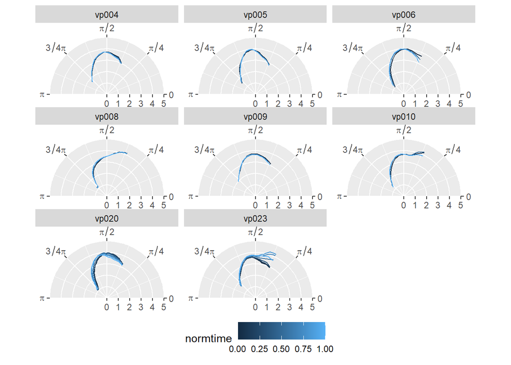

```r
dataset_ex_polar
```

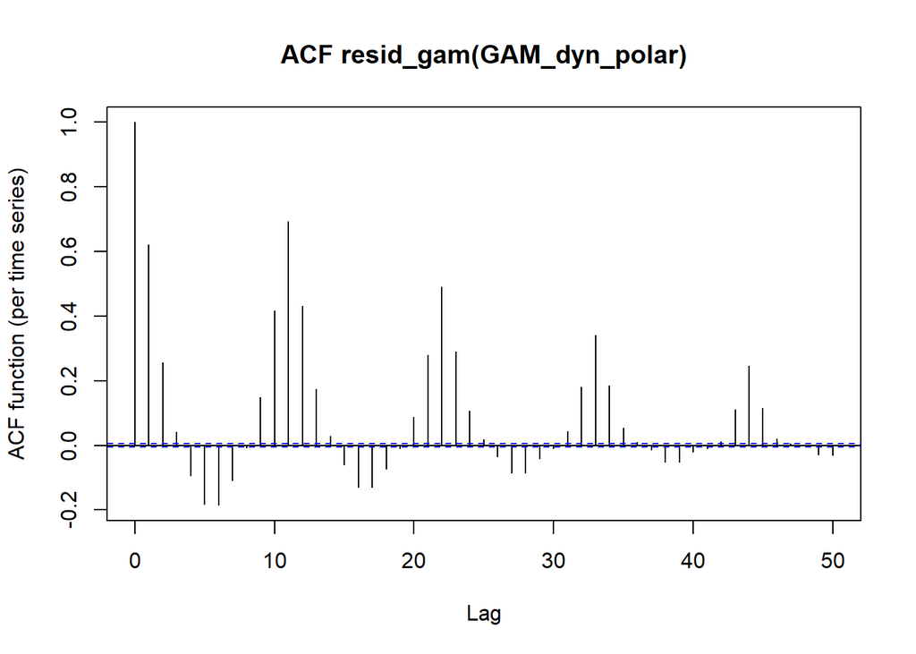

```r
GAM_dyn_polar <- bam(radius ~ participant + te(angle, normtime, by = factor(participant)),
            discrete = TRUE,
            family = 'scat',
            data = proc_polar_curves
)
AR1.rho <- acf_resid(GAM_dyn_polar)[2]
```

Taking autocorrelation into account:

```r
GAM_dyn_polar <- bam(radius ~ participant + te(angle, normtime, by = factor(participant)),
                          discrete = TRUE,
                        family = 'scat',
                        rho = AR1.rho,
                        AR.start = proc_polar_curves %>% pull(knot) == 0,
                        data = proc_polar_curves
)
summary(GAM_dyn_polar)
```

```
##
## Family: Scaled t(3.942,0.145)
## Link function: identity
##
## Formula:
## radius ~ participant + te(angle, normtime, by = factor(participant))
##
## Parametric coefficients:
##                   Estimate Std. Error t value Pr(>|t|)
## (Intercept)       3.042130   0.003755 810.105  < 2e-16 ***
## participantvp005  0.003078   0.005185   0.594   0.5527
## participantvp006 -0.052245   0.004416 -11.832  < 2e-16 ***
## participantvp008 -0.065456   0.004899 -13.361  < 2e-16 ***
## participantvp009  0.045623   0.005138   8.880  < 2e-16 ***
## participantvp010 -0.027115   0.004879  -5.557 2.75e-08 ***
## participantvp020 -0.010900   0.004354  -2.504   0.0123 *
## participantvp023  0.040888   0.004654   8.785  < 2e-16 ***
## ---
## Signif. codes:  0 '***' 0.001 '**' 0.01 '*' 0.05 '.' 0.1 ' ' 1
##
## Approximate significance of smooth terms:
##                                                edf Ref.df     F p-value
## te(angle,normtime):factor(participant)vp004  8.997  9.006  8033  <2e-16 ***
## te(angle,normtime):factor(participant)vp005 21.317 23.044  7671  <2e-16 ***
## te(angle,normtime):factor(participant)vp006 19.484 21.766 15771  <2e-16 ***
## te(angle,normtime):factor(participant)vp008 15.029 17.122 12245  <2e-16 ***
## te(angle,normtime):factor(participant)vp009  9.001  9.008  8072  <2e-16 ***
## te(angle,normtime):factor(participant)vp010 21.357 23.085  8652  <2e-16 ***
## te(angle,normtime):factor(participant)vp020 16.970 19.431 17687  <2e-16 ***
## te(angle,normtime):factor(participant)vp023 23.697 23.986  8303  <2e-16 ***
## ---
## Signif. codes:  0 '***' 0.001 '**' 0.01 '*' 0.05 '.' 0.1 ' ' 1
##
## R-sq.(adj) =  0.954   Deviance explained = 82.8%
## fREML = 1.6655e+05  Scale est. = 1         n = 118437
```

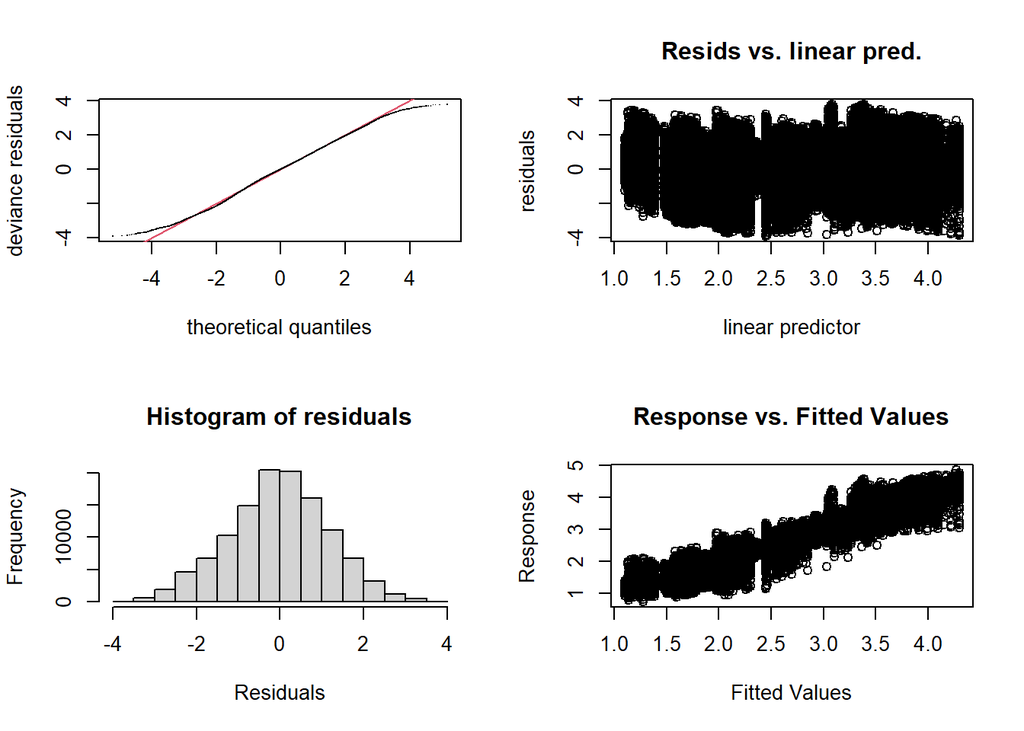

[output not shown]

[output cut: 77 more lines]

```r
gam.check(GAM_dyn_polar)
```

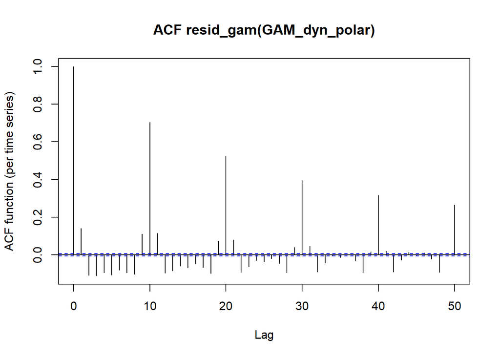

```r
acf_resid(GAM_dyn_polar)
```

Get the predictions and plot:

```r
normtime_grid <- (0:5)/5
pred <- get_predictions(GAM_dyn_polar,
                        cond = list(angle = angle_grid_plot,
                                    normtime = normtime_grid,
                                    participant = factor(rhotic_data_static_polar$participant) %>% levels()),
                        print.summary = FALSE)

gam_dyn_polar_flat_plot <- ggplot(pred) +
  aes(x = angle, y = normtime, group = participant) +
  geom_raster(aes(fill = fit)) +
  facet_grid(~ participant) +
  scale_x_reverse() +
  scale_fill_gradientn(colours = terrain.colors(10))

gam_polar_dyn_polar_plot <- ggplot(pred) +
  aes(x = angle, y = fit, group = normtime, color = normtime) +
  geom_path() +
  facet_wrap(vars(participant), ncol = 3) +
  radial_plot(5) +
  theme(legend.position = "bottom")
```

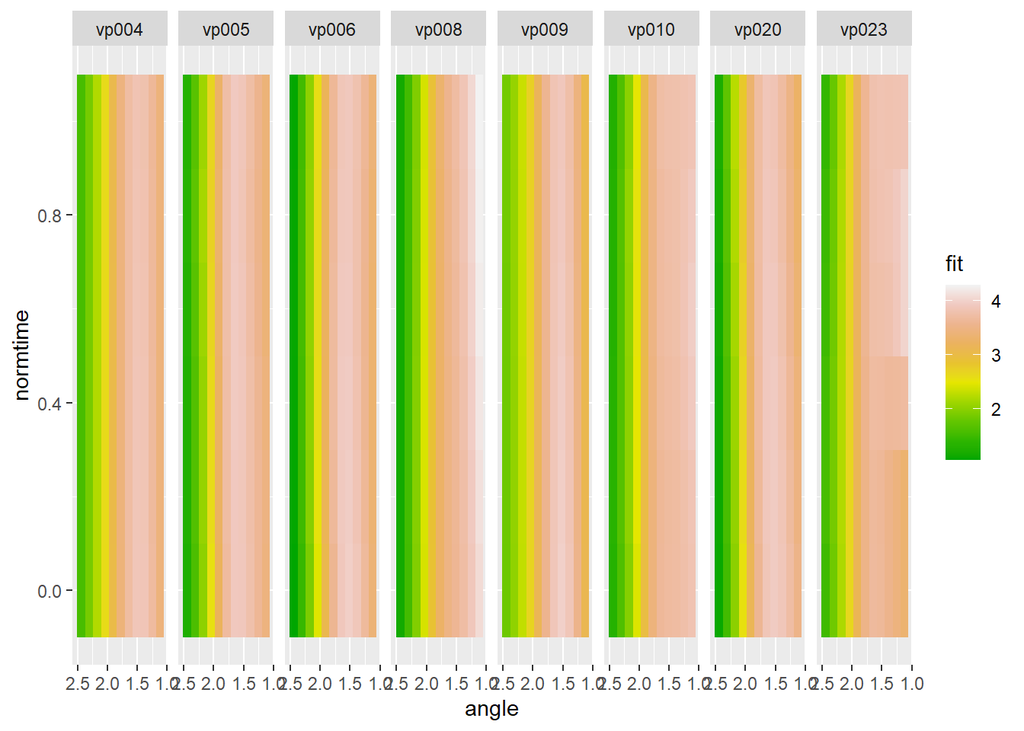

```r
gam_dyn_polar_flat_plot
```

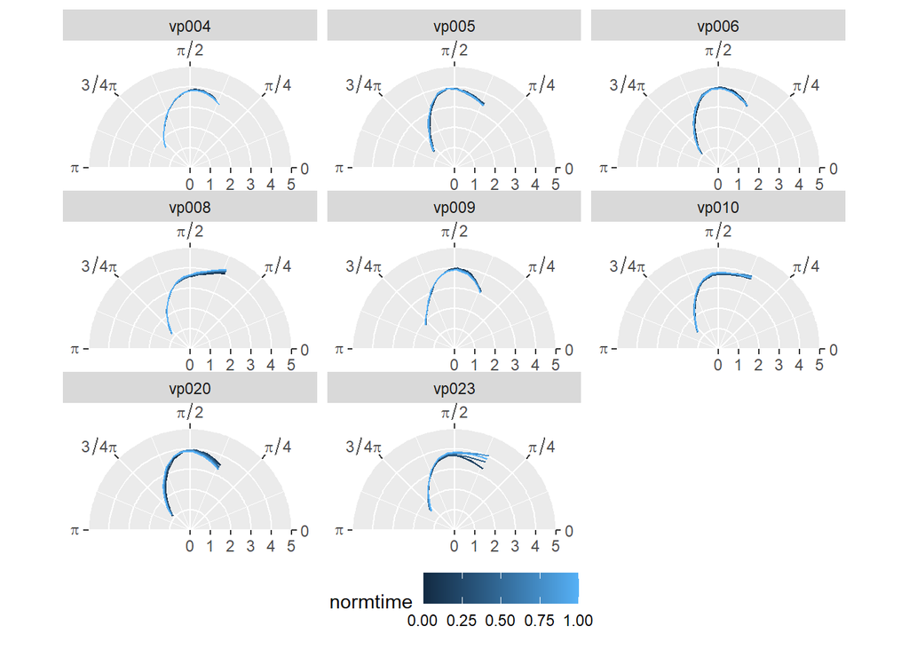

```r
gam_polar_dyn_polar_plot
```

This can give us a general hint about the articulation of the participants, but it would probably be more meaningful if we took the phonetic surrounding (e.g. following vowel) into account.

We could now look at the different tongue shapes of the participants at one time point to compare them, e.g. at 0.5/50 % of the normalized time:

```r
sec_time <- 0.5
pred <- get_predictions(GAM_dyn_polar,
                        cond = list(angle = angle_grid_plot,
                                    normtime = sec_time,
                                    participant = factor(rhotic_data_static_polar$participant) %>% levels()),
                        print.summary = FALSE)

sec_time_plot <- ggplot(pred) +
  aes(x = angle, y = fit, group = participant ) +
  geom_line(mapping = aes(color = participant)) +
  geom_ribbon(mapping = aes(ymin = fit - CI, ymax = fit + CI, fill = participant), alpha = 0.5) +
  theme_light() +
  radial_plot(5) +
  theme(legend.position = "bottom")
```

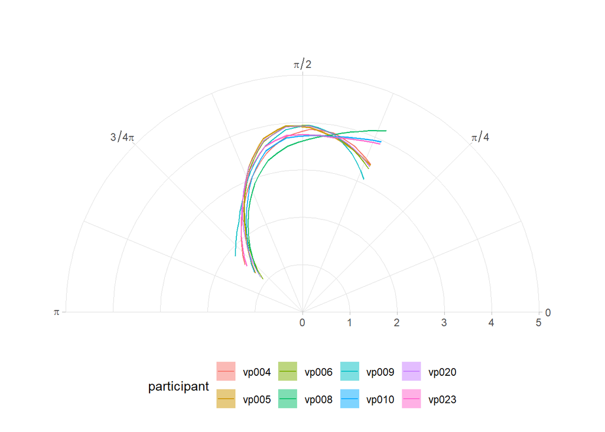

```r
sec_time_plot
```

Or we could look at one point on the shapes (= one angle value) and see how this point changes over time. Here we will take the “middle” $\pi$/2

```r
sec_angle <- pi/2
pred <- get_predictions(GAM_dyn_polar,
                        cond = list(angle = sec_angle,
                                    normtime = normtime_grid,
                                    participant = factor(rhotic_data_static_polar$participant) %>% levels()),
                        print.summary = FALSE)

sec_angle_plot <- ggplot(pred) +
  aes(x = normtime, y = fit, group = participant ) +
  geom_line(mapping = aes(color = participant)) +
  geom_ribbon(mapping = aes(ymin = fit - CI, ymax = fit + CI, fill = participant), alpha = 0.5) +
  theme_light() +
  ylab("Radius") +
  theme(legend.position = "bottom")
```

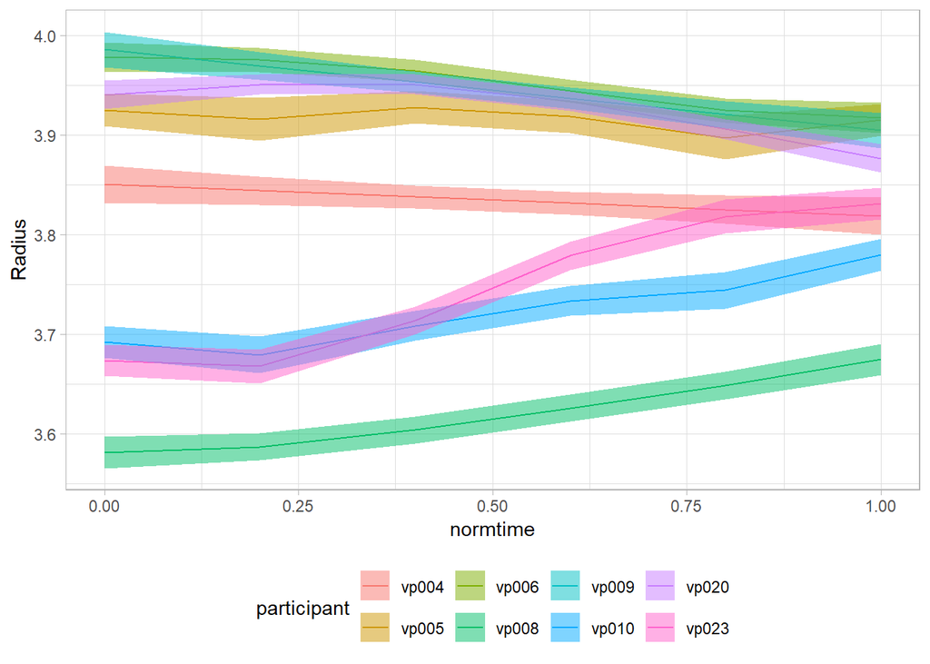

```r
sec_angle_plot
```

Or take the angle where the tongue tips approximately are (We’re taking the value $\pi * 7/16$:

```r
sec_angle <- pi*7/16
pred <- get_predictions(GAM_dyn_polar,
                        cond = list(angle = sec_angle,
                                    normtime = normtime_grid,
                                    participant = factor(rhotic_data_static_polar$participant) %>% levels()),
                        print.summary = FALSE)

sec_angle_plot_tt <- ggplot(pred) +
  aes(x = normtime, y = fit, group = participant ) +
  geom_line(mapping = aes(color = participant)) +
  geom_ribbon(mapping = aes(ymin = fit - CI, ymax = fit + CI, fill = participant), alpha = 0.5) +
  theme_light() +
  ylab("Radius") +
  theme(legend.position = "bottom")
```

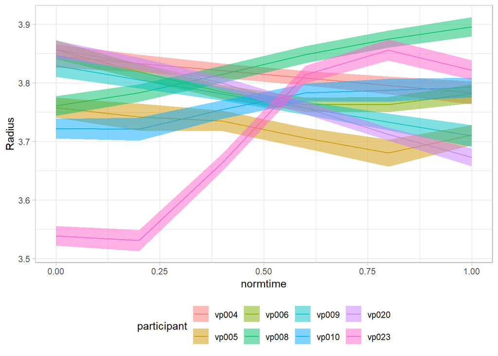

```r
sec_angle_plot_tt
```

It’s very interesting to see how the tongue tip of participant 23 moves upwards and then takes a turn at a normtime of around 80 %. It could as well be the case that other participants also do taps and move their tongue up and then downwards but that it cancels out due to them not doing it consistently at the same normtime.

#### cartesian coordinates

##### Univariate GAMM

We will now basically do the same thing as with the static data, but additionally, we will take into account the `normtime` variable. We’ve got a dimensional interaction between knot and normtime - this means that we need to introduce a te() smooth as above with the polar data:

```r
# create compound factor participant.dim for all combinations of participant and dimension
rhotic_data_long <- rhotic_data %>%
             pivot_longer(c(x_z, y_z), names_to = 'dimension', values_to = 'position') %>%
             unite("participant.dim", c(participant, dimension), sep = ".") %>%
             mutate(participant.dim = factor(participant.dim)) %>%
             # order to capture AR along knots
             arrange(sort_id, participant.dim, knot)

# calculate GAM
GAM_dyn <- bam(position ~ participant.dim +
             te(knot, normtime, by = participant.dim),
           data = rhotic_data_long,
           family = 'scat',
           discrete = TRUE)

# autocorellation:
AR1.rho_dyn <- acf_resid(GAM_dyn)[2]
```

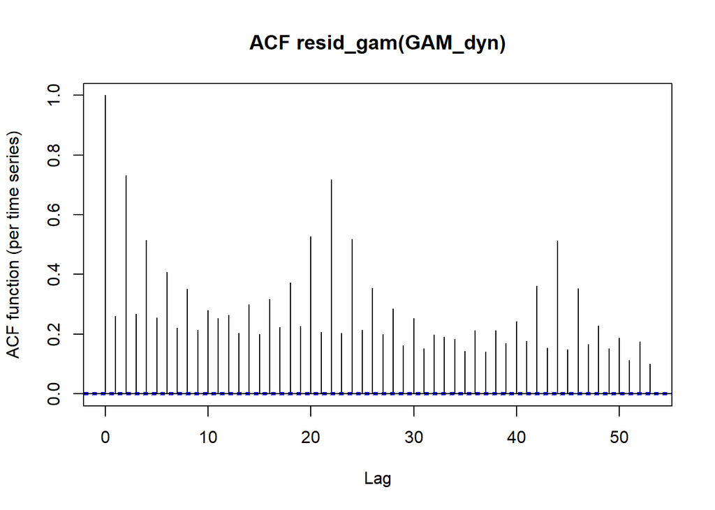

```r
# model that takes into account the autocorrelation in the residuals:
GAM_dyn <- bam(position ~ participant.dim +
                 te(knot, normtime, by = participant.dim),
           data = rhotic_data_long,
           rho = AR1.rho_dyn, # error model for residuals
            AR.start = rhotic_data_long %>% pull(knot) == 0,
           family = 'scat',
           discrete = TRUE)
summary(GAM_dyn)
```

```
##
## Family: Scaled t(5.775,0.122)
## Link function: identity
##
## Formula:
## position ~ participant.dim + te(knot, normtime, by = participant.dim)
##
## Parametric coefficients:
##                           Estimate Std. Error t value Pr(>|t|)
## (Intercept)              -0.042119   0.001729 -24.356  < 2e-16 ***
## participant.dimvp004.y_z  0.013707   0.001922   7.133 9.86e-13 ***
## participant.dimvp005.x_z -0.004814   0.002408  -1.999   0.0456 *
## participant.dimvp005.y_z  0.024642   0.002423  10.169  < 2e-16 ***
## participant.dimvp006.x_z -0.013992   0.002039  -6.863 6.77e-12 ***
## participant.dimvp006.y_z  0.004247   0.002038   2.084   0.0371 *
## participant.dimvp008.x_z  0.001428   0.002393   0.597   0.5506
## participant.dimvp008.y_z  0.010433   0.002399   4.349 1.37e-05 ***
## participant.dimvp009.x_z  0.002121   0.002401   0.883   0.3771
## participant.dimvp009.y_z  0.015740   0.002373   6.634 3.28e-11 ***
## participant.dimvp010.x_z -0.012062   0.002280  -5.291 1.22e-07 ***
## participant.dimvp010.y_z  0.011802   0.002298   5.136 2.81e-07 ***
## participant.dimvp020.x_z -0.001751   0.001982  -0.883   0.3771
## participant.dimvp020.y_z  0.021953   0.002012  10.911  < 2e-16 ***
## participant.dimvp023.x_z -0.011928   0.002134  -5.589 2.29e-08 ***
## participant.dimvp023.y_z  0.036123   0.002148  16.814  < 2e-16 ***
## ---
## Signif. codes:  0 '***' 0.001 '**' 0.01 '*' 0.05 '.' 0.1 ' ' 1
##
## Approximate significance of smooth terms:
##                                               edf Ref.df      F p-value
## te(knot,normtime):participant.dimvp004.x_z  8.999  9.005  38230  <2e-16 ***
## te(knot,normtime):participant.dimvp004.y_z 13.097 15.016  22835  <2e-16 ***
## te(knot,normtime):participant.dimvp005.x_z 20.788 22.664  26574  <2e-16 ***
## te(knot,normtime):participant.dimvp005.y_z 21.218 22.955  26997  <2e-16 ***
## te(knot,normtime):participant.dimvp006.x_z 20.044 22.183  44173  <2e-16 ***
## te(knot,normtime):participant.dimvp006.y_z 18.533 20.909  49100  <2e-16 ***
## te(knot,normtime):participant.dimvp008.x_z 22.054 23.454  25358  <2e-16 ***
## te(knot,normtime):participant.dimvp008.y_z 22.085 23.472  25934  <2e-16 ***
## te(knot,normtime):participant.dimvp009.x_z 11.419 12.978  30418  <2e-16 ***
## te(knot,normtime):participant.dimvp009.y_z  9.056  9.111  43785  <2e-16 ***
## te(knot,normtime):participant.dimvp010.x_z 22.129 23.514  28889  <2e-16 ***
## te(knot,normtime):participant.dimvp010.y_z 23.302 23.914  29358  <2e-16 ***
## te(knot,normtime):participant.dimvp020.x_z  9.041  9.082 118556  <2e-16 ***
## te(knot,normtime):participant.dimvp020.y_z 20.000 22.200  49245  <2e-16 ***
## te(knot,normtime):participant.dimvp023.x_z 21.853 23.398  35494  <2e-16 ***
## te(knot,normtime):participant.dimvp023.y_z 23.916 23.997  35140  <2e-16 ***
## ---
## Signif. codes:  0 '***' 0.001 '**' 0.01 '*' 0.05 '.' 0.1 ' ' 1
##
## R-sq.(adj) =  0.977   Deviance explained = 89.9%
## fREML = 3.6199e+05  Scale est. = 1         n = 236874
```

Check the dynamic GAM and the distribution of residuals:

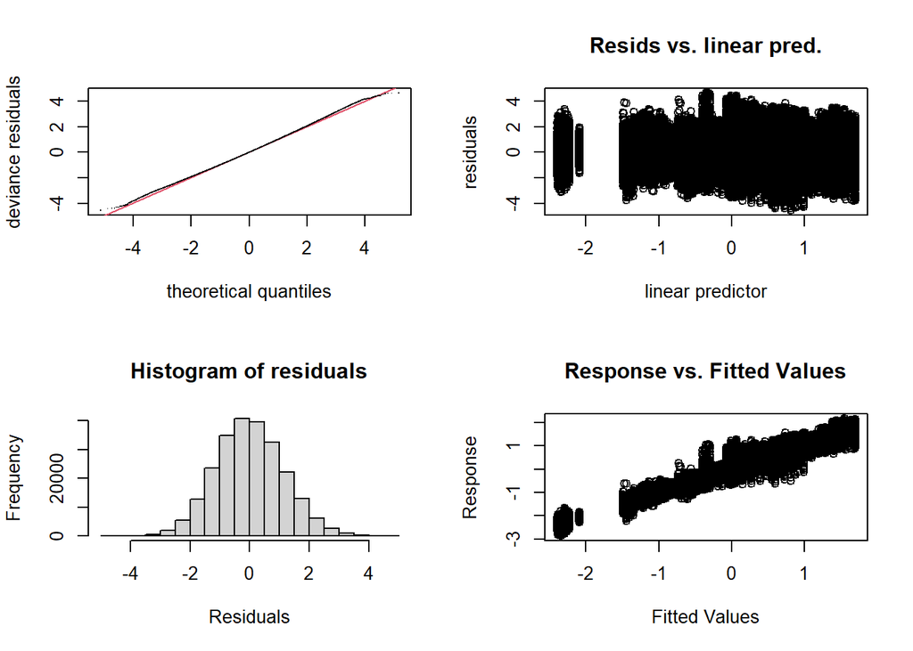

[output not shown]

[output cut: 251 more lines]

```r
gam.check(GAM_dyn)
```

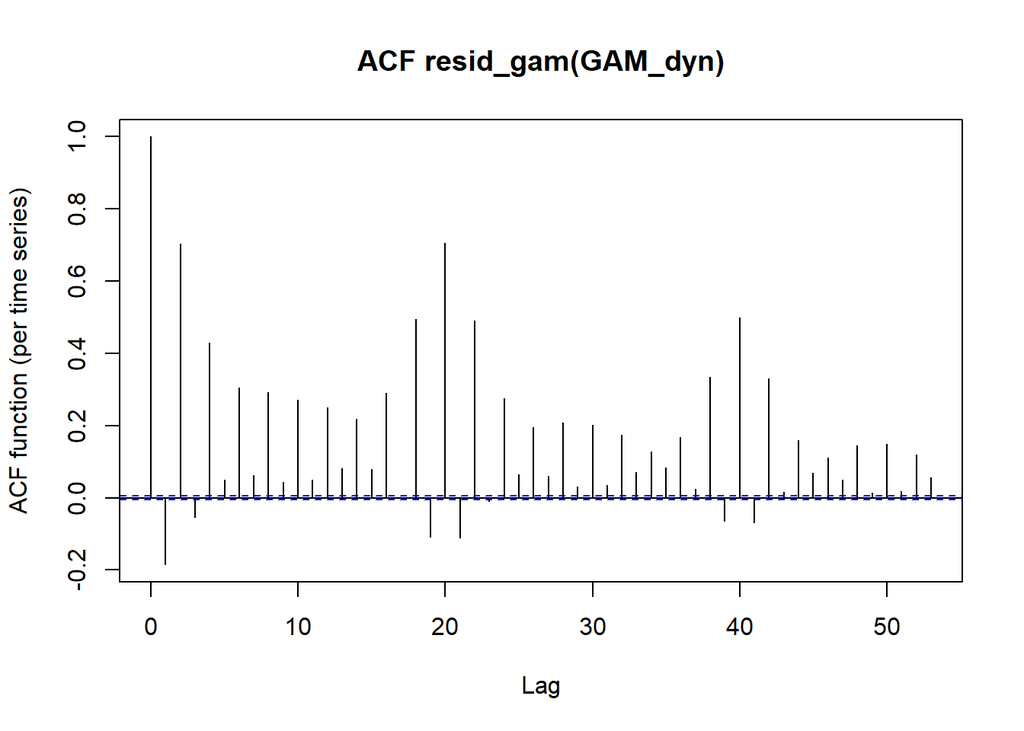

```r
acf_resid(GAM_dyn)
```

Now that we have our model, we can plot the predictions of the tongue movement over time per participant.

```r
gam_dyn_pred <- get_predictions(GAM_dyn,
                        cond = list(knot = 0:10,
                                    normtime = c(0,0.25,0.5,0.75,1), # five time points
                                    participant.dim = rhotic_data_long$participant.dim %>% levels()),
                        se = FALSE,
                        print.summary = FALSE) %>%
  separate_wider_delim(participant.dim, ".", names = c("participant", "dimension")) %>%
  pivot_wider(names_from = dimension, values_from = "fit") %>%
  mutate(part.normtime = paste0(participant, ".", normtime)) # for plotting

gam_dyn_pred_plot <- ggplot(gam_dyn_pred) +
  aes(x_z, y_z, group = part.normtime, color = normtime) +
  geom_path() +
  # geom_point(aes(color = participant)) +
  geom_text(aes(label = knot), check_overlap = TRUE,
            nudge_x = .05, nudge_y = .05, show.legend = FALSE) +
  facet_wrap(vars(participant), ncol = 4) +
  theme(legend.position = "bottom")
```

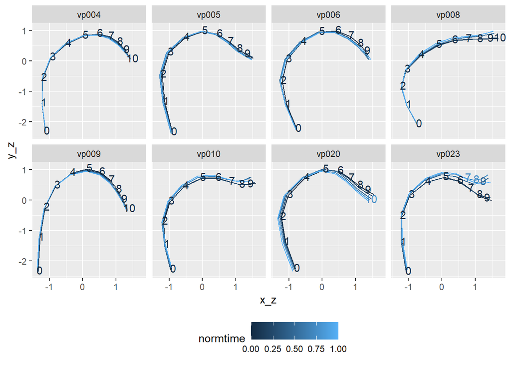

```r
gam_dyn_pred_plot
```

We can observe great differences in the tongue movements of the participants. Some participants barely show a movement of the tongue during the articulation of the rhotic (participant 4, 5, 6, 9), while the movement of other participants is rather big. It is interesting to see that the tongue movement of the participants seemingly using front rhotics (participant 8, 10 and 23) is larger in general. But there are also individual differences within this group - while participant 8 seems to mainly move their tongue upwards, the predicted splines of participant 10 and 23 look like they first move upwards, then move downwards. If we tried to interpret these results, we could say that the predictions of participant 10 and 23 look more like taps. The only person whose tongue splines look like they produce a back/uvular rhotic and has a lot of tongue movement is participant 20. Their tongue tip clearly moves downwards as time progresses.

We chose to display the predictions using five time points (at 0 %, 25 %, 50 %, 75 % and 100 % of the time) in the plot above. Of course we could also change that and display more time points to get a higher resolution on the time axis:

```r
gam_dyn_pred_f <- get_predictions(GAM_dyn,
                        cond = list(knot = 0:10,
                                    normtime = (0:10)/10,
                                    participant.dim = rhotic_data_long$participant.dim %>% levels()),
                        se = FALSE,
                        print.summary = FALSE) %>%
  separate_wider_delim(participant.dim, ".", names = c("participant", "dimension")) %>%
  pivot_wider(names_from = dimension, values_from = "fit") %>%
  mutate(part.normtime = paste0(participant, ".", normtime)) # for plotting

gam_dyn_pred_plot_f <- ggplot(gam_dyn_pred_f) +
  aes(x_z, y_z, group = part.normtime, color = normtime) +
  geom_path() +
  # geom_point(aes(color = participant)) +
  # geom_text(aes(label = knot), check_overlap = TRUE,
            # nudge_x = .05, nudge_y = .05, show.legend = FALSE) +
  facet_wrap(vars(participant), ncol = 4) +
  theme(legend.position = "bottom")
```

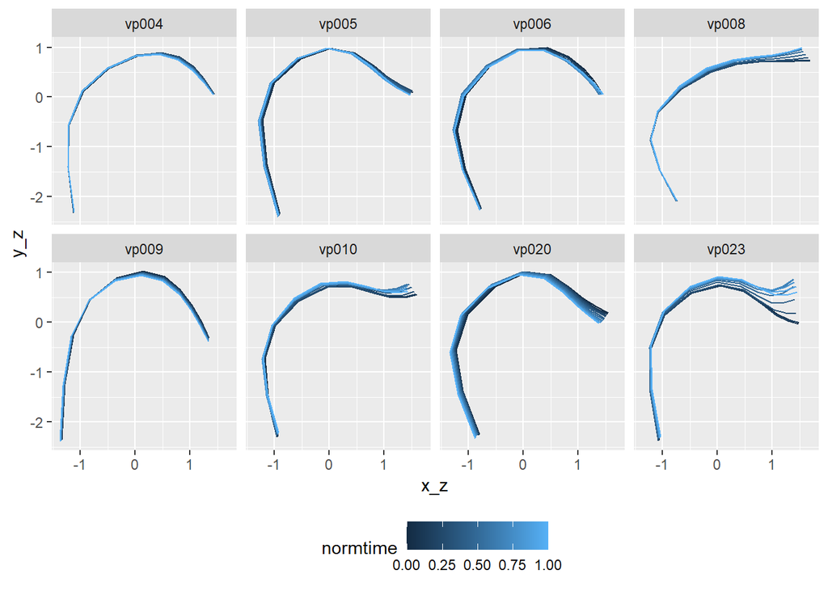

```r
gam_dyn_pred_plot_f
```

### (M)FPCA

#### polar coordinates

```r
proc_polar_curves_norm <- proc_polar_curves %>%
  group_by(participant, clip_id, angle) %>%
  # interpolation
  reframe(bind_cols(
    approx(normtime, radius, normtime_grid, rule = 2) %>% as_tibble()
    )) %>%
  rename(normtime = x,radius = y)
```

Now we create the funData object:

```r
# build a funData object

argvals <- list(normtime=normtime_grid, angle=angle_grid)

# X: array of dim c(nFrames, length(normtime_grid), length(angle_grid))
X <- proc_polar_curves_norm %>%
  pivot_wider(id_cols = c(clip_id, normtime), names_from = angle, values_from = radius) %>%
  select(-normtime) %>%
  nest(.by = clip_id) %>%
  pull(data) %>%
  lapply(as.matrix) %>%
  abind(along = 0)

fpca_polar_dyn_curves <- funData(argvals, X)
fpca_polar_dyn_curves
```

```
## Functional data with 2162 observations of 2-dimensional support
## argvals:
##  0 0.2 ... 1     (6 sampling points)
##  1.132009 1.262495 ... 2.436868      (11 sampling points)
## X:
##  array of size 2162 x 6 x 11
```

We’ve now got a funData object with 6 sampling points in regard to normtime and 11 sampling points in regard to angle (= our fake knots).

Calculate the FPCA:

```r
# FCP_TPA
fpca_polar_dyn <- MFPCA(fpca_polar_dyn_curves %>% multiFunData(),
              M = 5, # number of principle components to calculate
              # FCP_TPA is one of the possible multidim. support parametrizations
              # alphaRange = "A list of length 2 with entries v and w, containing the range of smoothness parameters to test for each direction" (source: MFPCA documentation)
              uniExpansions = list(list(type = "FCP_TPA",
                                        npc = 5,
                                        alphaRange = list(v = c(10^-2, 10^2), w = c(10^-3, 10^3))))
)
```

```r
# Prop of explained var
PropExpVar <- round(fpca_polar_dyn$values/sum(fpca_polar_dyn$values), digits = 3)
PropExpVar
```

```
## [1] 0.534 0.248 0.108 0.077 0.033
```

```r
nPC <- 2 # we only look at the first 2 PCs from now on

# scores st. dev.
sdFun <- fpca_polar_dyn$values %>% sqrt()

# PC curves to be plotted
PCcurves_polar_dyn <- expand_grid(PC = 1:nPC,
                        fractionOfStDev = c(-1, 0, 1)) %>%
  group_by(PC, fractionOfStDev) %>%
  reframe(
    (fpca_polar_dyn$meanFunction[[1]]@X[1,,] + fractionOfStDev * sdFun[PC] * fpca_polar_dyn$functions[[1]]@X[PC,,]) %>%
      `colnames<-`(angle_grid) %>%
      as_tibble() %>%
      bind_cols(normtime = normtime_grid)
  ) %>%
  pivot_longer(cols = -c(PC, fractionOfStDev, normtime), names_to = "angle", values_to = "radius") %>%
  mutate(angle = as.numeric(angle))

# Plot
FPCA_polar_dyn_curves_plot <- ggplot(PCcurves_polar_dyn %>% rename(`score/std` = fractionOfStDev)) +
  aes(x = angle, y = radius, group = normtime, color = normtime) +
  geom_path() +
  facet_grid(PC ~ `score/std`,
             labeller = labeller(PC = ~ str_glue("PC{.x}"), `score/std` = label_both),
             ) +
  radial_plot(5) +
  theme(legend.position = "bottom")
```

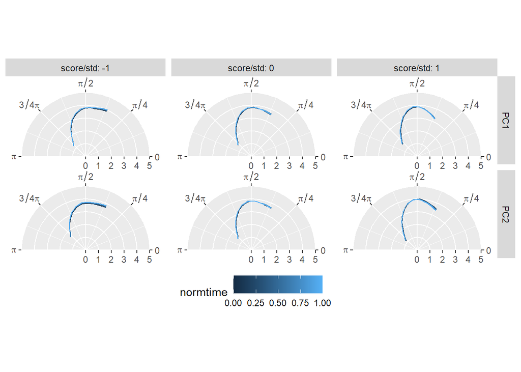

```r
FPCA_polar_dyn_curves_plot
```

The PCs again capture the whole variation of the dataset, so in this case the whole variation of tongue movements over time. The top row shows the predictions of the PC1 score, the bottom row the ones of PC2 scores. On the middle columns, the mean tongue movement is pictured. On the left hand side, the deviation from the mean of -1 standard deviation of the PC scores is pictured, on the right hand side, +1 standard deviation.

The mean function is a tongue shape with an arched tongue dorsum and a tongue tip that is rather neutral (it’s not exactly pointing down but it’s also not pointing upwards as well). There is hardly any movement, if one looks closely, one can see that the tongue moves upwards slightly as a whole. PC1 seems to describe a variation of the movement in the tongue tip – on the -1 sd plot, the tongue tip moves upwards as time progresses, on the +1 sd side, the tongue tip moves very slightly downwards. PC2 captures a variation of the whole tongue moving either upwards (-1 sd) or downwards (+1 sd).

Now we want to see if there is a difference in the PC scores between the participants:

```r
# collect PC scores
PCscores_polar_dyn <- fpca_polar_dyn$scores[, 1:nPC] %>%
  `colnames<-`(paste0("s", 1:nPC)) %>%
  as_tibble() %>%
  bind_cols(proc_polar_curves_norm %>% distinct(clip_id, participant), .)

# boxplots PC scores by participant
FPCA_polar_dyn_boxplot <- PCscores_polar_dyn %>%
  pivot_longer(cols = paste0("s", 1:nPC),
               names_to = "PC", values_to = "score") %>%
  filter(PC %in% str_c("s", 1:nPC)) %>%
  ggplot() +
  aes(x = participant, y = score, color = participant) +
  geom_boxplot() +
  facet_wrap(~ PC) +
  theme(legend.position = "bottom")
```

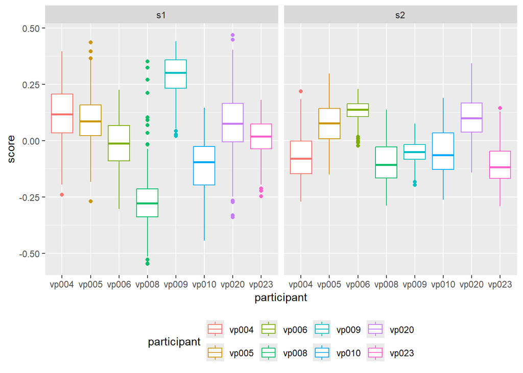

```r
FPCA_polar_dyn_boxplot
```

There are differences between the participants in both of the PC scores so it seems like they are both correlated to the variable `participant`. Again, we can calculate linear models to confirm that the scores are correlated to `participant` and plot the predicted tongue movement of the participant made by the linear models.

```r
mod_s1 <- lm(s1 ~ participant, data = PCscores_polar_dyn)
mod_s1 %>% summary()
```

```
##
## Call:
## lm(formula = s1 ~ participant, data = PCscores_polar_dyn)
##
## Residuals:
##      Min       1Q   Median       3Q      Max
## -0.41907 -0.07250  0.00280  0.07344  0.61953
##
## Coefficients:
##                   Estimate Std. Error t value Pr(>|t|)
## (Intercept)       0.112197   0.009184  12.216  < 2e-16 ***
## participantvp005 -0.022418   0.011218  -1.998  0.04580 *
## participantvp006 -0.128187   0.011200 -11.445  < 2e-16 ***
## participantvp008 -0.381219   0.011319 -33.680  < 2e-16 ***
## participantvp009  0.177800   0.012946  13.733  < 2e-16 ***
## participantvp010 -0.223412   0.011200 -19.947  < 2e-16 ***
## participantvp020 -0.033546   0.011177  -3.001  0.00272 **
## participantvp023 -0.098814   0.011189  -8.832  < 2e-16 ***
## ---
## Signif. codes:  0 '***' 0.001 '**' 0.01 '*' 0.05 '.' 0.1 ' ' 1
##
## Residual standard error: 0.1132 on 2154 degrees of freedom
## Multiple R-squared:  0.6171, Adjusted R-squared:  0.6159
## F-statistic: 495.9 on 7 and 2154 DF,  p-value: < 2.2e-16
```

```r
mod_s2 <- lm(s2 ~ participant, data = PCscores_polar_dyn)
mod_s2 %>% summary()
```

```
##
## Call:
## lm(formula = s2 ~ participant, data = PCscores_polar_dyn)
##
## Residuals:
##      Min       1Q   Median       3Q      Max
## -0.24187 -0.05704 -0.00175  0.05543  0.28821
##
## Coefficients:
##                   Estimate Std. Error t value Pr(>|t|)
## (Intercept)      -0.069449   0.006857 -10.128  < 2e-16 ***
## participantvp005  0.143123   0.008376  17.088  < 2e-16 ***
## participantvp006  0.199301   0.008362  23.833  < 2e-16 ***
## participantvp008 -0.027924   0.008451  -3.304 0.000968 ***
## participantvp009  0.016836   0.009666   1.742 0.081690 .
## participantvp010  0.021431   0.008362   2.563 0.010449 *
## participantvp020  0.168867   0.008345  20.236  < 2e-16 ***
## participantvp023 -0.034130   0.008354  -4.086 4.56e-05 ***
## ---
## Signif. codes:  0 '***' 0.001 '**' 0.01 '*' 0.05 '.' 0.1 ' ' 1
##
## Residual standard error: 0.08454 on 2154 degrees of freedom
## Multiple R-squared:  0.5402, Adjusted R-squared:  0.5387
## F-statistic: 361.5 on 7 and 2154 DF,  p-value: < 2.2e-16
```

Plot prediction PC1:

```r
predCurves_s1 <- emmeans(mod_s1, pairwise ~ participant)$emmeans %>%
  as_tibble() %>%
  group_by(participant) %>%
reframe(
    (fpca_polar_dyn$meanFunction[[1]]@X[1,,] + emmean * fpca_polar_dyn$functions[[1]]@X[s,,]) %>%
      `colnames<-`(angle_grid) %>%
      as_tibble() %>%
      bind_cols(normtime = normtime_grid)
  ) %>%
  pivot_longer(cols = -c(participant, normtime), names_to = "angle", values_to = "radius") %>%
  mutate(angle = as.numeric(angle))

FPCA_polar_dyn__pred_s1_plot <- ggplot(predCurves_s1) +
  aes(x = angle, y = radius, group = normtime, color = normtime) +
  geom_path() +
  facet_wrap(vars(participant), ncol = 3) +
  radial_plot(5) +
  theme(legend.position = "bottom")
```

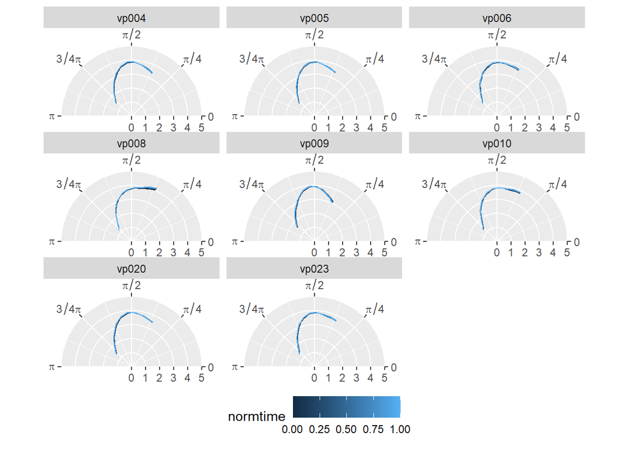

```r
FPCA_polar_dyn__pred_s1_plot
```

As already expected, we can see a lot of variation in the tongue tip area of the participant’s. What’s interesting this time are the differences in the tongue movement. While the tongue of participant 6, 8 and 10 show an upward movement, the tongue of participant 9 moves downwards. Participants 4, 5 and 20 show barely any movement at all. Participant 23’s tongue first moves upwards then downwards again.

```r
predCurves_s2 <- emmeans(mod_s2, pairwise ~ participant)$emmeans %>%
  as_tibble() %>%
  group_by(participant) %>%
reframe(
    (fpca_polar_dyn$meanFunction[[1]]@X[1,,] + emmean * fpca_polar_dyn$functions[[1]]@X[s,,]) %>%
      `colnames<-`(angle_grid) %>%
      as_tibble() %>%
      bind_cols(normtime = normtime_grid)
  ) %>%
  pivot_longer(cols = -c(participant, normtime), names_to = "angle", values_to = "radius") %>%
  mutate(angle = as.numeric(angle))

FPCA_polar_dyn__pred_s2_plot <- ggplot(predCurves_s2) +
  aes(x = angle, y = radius, group = normtime, color = normtime) +
  geom_path() +
  facet_wrap(vars(participant), ncol = 3) +
  radial_plot(5) +
  theme(legend.position = "bottom")
```

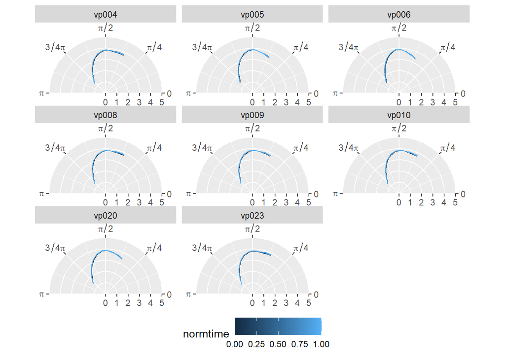

```r
FPCA_polar_dyn__pred_s2_plot
```

Coretta, Stefano, and Georges Sakr. 2025. “Stefanocoretta/Mv_uti: V1.1.” Zenodo. https://doi.org/10.5281/zenodo.15335918.

Gubian, Michele. 2025. “Analysis of Uni- and Multi-Dimensional Contours with GAMs and Functional PCA: An Application to Ultrasound Tongue Imaging.” https://github.com/uasolo/FPCA-phonetics-workshop/blob/master/presentations/UTI/UTI_analysis_code.html.

Gubian, Michele, Francisco Torreira, and Lou Boves. 2015. “Using Functional Data Analysis for Investigating Multidimensional Dynamic Phonetic Contrasts.” *Journal of Phonetics* 49: 16–40. https://doi.org/10.1016/j.wocn.2014.10.001.

Wieling, Martijn. 2018. “Analyzing Dynamic Phonetic Data Using Generalized Additive Mixed Modeling: A Tutorial Focusing on Articulatory Differences Between L1 and L2 Speakers of English.” *Journal of Phonetics* 70: 86–116. https://doi.org/10.1016/j.wocn.2018.03.002.